# Statistical inference, part II

Parametric tests

Eva Freyhult

NBIS, SciLifeLab

April 23, 2024

# Parametric tests

If the null distribution was already known (or could be computed based on a few assumptions) resampling would not be necessary.

We can follow the same steps as before to perform a hypothesis test:

1. Define $H_0$ and $H_1$
2. Select an appropriate significance level, $\alpha$
3. Select appropriate test statistic, $T$, and compute the observed value, $t_{obs}$
4. Assume that $H_0$ is true and derive the null distribution of the test statistic based on appropriate assumptions.
5. Compare the observed value, $t_{obs}$, with the null distribution and compute a p-value. The p-value is the probability of observing a value at least as extreme as the observed value, if $H_0$ is true.
6. Based on the p-value either accept or reject $H_0$.

## One sample, mean

A one sample test of means compares the mean of a sample to a prespecified value.

The hypotheses:

$$H_0: \mu = \mu_0 \\
H_1: \mu \neq \mu_0$$

The alternative hypothesis, $H_1,$ above is for the **two sided** hypothesis test.

Other options are the **one sided** alternatives;

- $H_1: \mu > \mu_0$ or
- $H_1: \mu < \mu_0$.

## One sample, mean, mouse example

We know that the weight of a mouse on normal diet is normally distributed with mean 24.0 g and standard deviation 3.0 g. To investigate if body weight of mice is changed by high-fat diet, 10 mice are fed on high-fat diet for three weeks. The mean weight of the high-fat mice is 26.0 g, is there reason to believe that high fat diet affect mice body weight?

## One sample, mean, mouse example

The body weight of a mouse is $X \sim N(\mu, \sigma),$ where $\mu=24.0$ and $\sigma=3.0$

Hence, the mean weight of $n=10$ independent mice from the same population is
$$\bar X \sim N\left(\mu, \frac{\sigma}{\sqrt{n}}\right).$$

## One sample, mean, mouse example

The body weight of a mouse is $X \sim N(\mu, \sigma),$ where $\mu=24.0$ and $\sigma=3$.

Hence, the mean weight of $n=10$ independent mice from the same population is
$$\bar X \sim N\left(\mu, \frac{\sigma}{\sqrt{n}}\right).$$

An appropriate test statistic is

$$Z = \frac{\bar X - \mu}{\frac{\sigma}{\sqrt{n}}}$$
If $\sigma$ is known, $Z\sim N(0,1)$.

## One sample t-test

For small $n$ and unknown $\sigma$, the test statistic

$$t = \frac{\bar X - \mu}{\frac{s}{\sqrt{n}}}$$

is t-distributed with $df=n-1$ degrees of freedom.

## Two samples, mean

A two sample test of means is used to determine if two population means are equal.

Two independent samples are collected (one from each population) and the means are compared. Can for example be used to determine if a treatment group is different compared to a control group, in terms of the mean of a property of interest.

The hypotheses;

$$H_0: \mu_2 = \mu_1\\
H_1: \mu_2 \neq \mu_1$$

The above $H_1$ is two-sided. One-sided alternatives could be
$$H_1: \mu_2 > \mu_1\\
\mathrm{or}\\
H_1: \mu_2 < \mu_1$$

## Two samples, mean

Assume that observations from both populations are normally distributed;

$$\begin{aligned}
X_1 \sim N(\mu_1, \sigma_1) \\
X_2 \sim N(\mu_2, \sigma_2)
\end{aligned}$$

Then it follows that the sample means will also be normally distributed;

$$\begin{aligned}
\bar X_1 \sim N(\mu_1, \sigma_1/\sqrt{n_1}) \\
\bar X_2 \sim N(\mu_2, \sigma_2/\sqrt{n_2})
\end{aligned}$$

The mean difference $D = \bar X_2 - \bar X_1$ is thus also normally distributed:

$$D = \bar X_2 - \bar X_1 = N\left(\mu_2-\mu_1, \sqrt{\frac{\sigma_2^2}{n_2} + \frac{\sigma_1^2}{n_1}}\right)$$

## Two samples, mean

If $H_0$ is true:
$$D = \bar X_2 - \bar X_1 = N\left(0, \sqrt{\frac{\sigma_2^2}{n_2} + \frac{\sigma_1^2}{n_1}}\right)$$

The test statistic:
$$Z = \frac{\bar X_2 - \bar X_1}{\sqrt{\frac{\sigma_2^2}{n_2} + \frac{\sigma_1^2}{n_1}}}$$
is standard normal, i.e. $Z \sim N(0,1)$.

However, note that the test statistic require the standard deviations $\sigma_1$ and $\sigma_2$ to be known.

## Two samples, mean

### Unknown variances

What if the population standard deviations are not known?

## Two samples, mean

### Unknown variances, large sample sizes

If the sample sizes are large, we can replace the known standard deviations with our sample standard deviations and according to the central limit theorem assume that

$$Z = \frac{\bar X_2 - \bar X_1}{\sqrt{\frac{s_2^2}{n_2} + \frac{s_1^2}{n_1}}} \sim N(0,1)$$

and proceed as before.

## Two samples, mean

### Unknown variances, small sample sizes

Either assume equal variances and proceed with Student’s t-test or use Welch’s t-test for unequal variances.

## Two samples, mean

### Unknown equal variances, small sample sizes

**Student’s t-test**

Assume equal variances in the two populations and compute the pooled sample standard deviation;

$$s_p^2 = \frac{(n_1-1)s_1^2 + (n_2-1)s_2^2}{n_1+n_2-2}$$

and the test statistic

$$t = \frac{\bar X_1 - \bar X_2}{\sqrt{s_p^2(\frac{1}{n_1} + \frac{1}{n_2})}},$$

which is t-distributed with $n_1+n_2-2$ degrees of freedom.

## Two samples, mean

### Unknown variances, small sample sizes

**Welch’s t-test**

For unequal variances the following test statistic can be used;

$$t = \frac{\bar X_2 - \bar X_1}{\sqrt{\frac{s_2^2}{n_2} + \frac{s_1^2}{n_1}}}$$
$t$ is $t$-distributed and the degrees of freedom can be computed using Welch approximation.

Fortunately, the t-test is implemented in R, e.g. in the function `t.test` in the R-package `stats`. This function can compute both Student’s t-test with equal variances and Welch’s t-test with unequal variances.

## One sample, proportions, pollen example

Assume that the proportion of pollen allergy in Sweden is known to be $0.3$. Observe 100 people from Uppsala, 42 of these are allergic to pollen. Is there a reason to believe that the proportion of pollen allergic in Uppsala $\pi > 0.3$?

## One sample, proportions, pollen example

### Null and alternative hypothesis

Denote the unknown (Uppsala) populations proportion of pollen allergy $\pi$ and define $H_0$ and $H_1$.

$$H_0: \pi=\pi_0 \\
H_1: \pi>\pi_0,$$

where $\pi_0$ is the known proportion under $H_0$ (here 0.3, the proportion in Sweden).

## One sample, proportions, pollen example

### Null and alternative hypothesis

$H_0: \pi=\pi_0, H_1: \pi>\pi_0,$

### Significance level, $\alpha$

$\alpha = 0.05$

## One sample, proportions, pollen example

### Null and alternative hypothesis

$H_0: \pi=\pi_0, H_1: \pi>\pi_0,$

### Significance level, $\alpha$

$\alpha = 0.05$

### Test statistic

Here, we will use $X$, the number of allergic persons in a random sample of size $n=100$.

The observed value is $x_{obs} = 42$.

## One sample, proportions, pollen example

### Null and alternative hypothesis

$H_0: \pi=\pi_0, H_1: \pi>\pi_0,$

### Significance level, $\alpha$

$\alpha = 0.05$

### Test statistic

$X$, the number of allergic persons in a random sample of size $n=100$. $x_{obs} = 42$.

### Null distribution

$X$ is binomially distributed under the null hypothesis.

$$X \sim Bin(n=100, p=0.3)$$

There is no need to use resampling here, so we can use the binomial distribution to answer the question.

## One sample, proportions, pollen example

### Null and alternative hypothesis

$H_0: \pi=\pi_0, H_1: \pi>\pi_0,$

### Significance level, $\alpha$

$\alpha = 0.05$

### Test statistic

$X$, the number of allergic persons in a random sample of size $n=100$. $x_{obs} = 42$.

### Null distribution

$X \sim Bin(n=100, p=0.3)$

### p-value

The probability of $x_{obs}$ or something higher,

$p = P(X \geq 42) = 1 - P(X \leq 41)$ = [`1-pbinom(41,100,0.3)`] = 0.007174

## One sample, proportions, pollen example

### Null and alternative hypothesis

$H_0: \pi=\pi_0, H_1: \pi>\pi_0,$

### Significance level, $\alpha$

$\alpha = 0.05$

### Test statistic

$X$, the number of allergic persons in a random sample of size $n=100$. $x_{obs} = 42$.

### Null distribution

$X \sim Bin(n=100, p=0.3)$

### p-value

$p = P(X \geq 42)$ = 0.007174

### Accept or recject $H_0$?

## One sample, proportions, pollen example

### Null and alternative hypothesis

$H_0: \pi=\pi_0, H_1: \pi>\pi_0,$

### Significance level, $\alpha$

$\alpha = 0.05$

### Test statistic

$X$, the number of allergic persons in a random sample of size $n=100$. $x_{obs} = 42$.

### Null distribution

$X \sim Bin(n=100, p=0.3)$

### p-value

$p = P(X \geq 42)$ = 0.007174

### Accept or recject $H_0$?

As $p<0.05$ $H_0$ is rejected and we conclude that there is reason to believe that the proportion of pollen allergic in Uppsala is higher than 0.3.

## One sample, proportions, pollen example

In R

```r
binom.test(42, 100, 0.3, alternative="greater")
```

```
    Exact binomial test

data:  42 and 100
number of successes = 42, number of trials = 100, p-value = 0.007
alternative hypothesis: true probability of success is greater than 0.3
95 percent confidence interval:
 0.3365 1.0000
sample estimates:
probability of success
                  0.42
```

## One sample, proportions, pollen example

An alternative approach is to use the Central limit theorem, and use the normal approximation (see details in lecture notes).

Central Limit Theorem

> The sum of $n$ independent and equally distributed random variables is normally distributed, if $n$ is large enough.

## Variance test

The test of equal variance in two groups is based on the null hypothesis

$$H_0: \sigma_1^2 = \sigma_2^2$$

If the two samples both come from two populations with normal distributions, the sample variances

$$S_1^2 = \frac{1}{n_1-1} \sum_{i=1}^{n_1} (X_{1i}-\bar X_1)^2\\
S_2^2 = \frac{1}{n_2-1} \sum_{i=1}^{n_2} (X_{2i}-\bar X_2)^2$$

It can be shown that $\frac{(n_1-1)S_1^2}{\sigma_1^2} \sim \chi^2(n_1-1)$ and $\frac{(n_2-1)S_2^2}{\sigma_2^2} \sim \chi^2(n_2-1)$.

Hence, the test statistic for comparing the variances of two groups

$$F = \frac{S_1^2}{S_2^2}$$
is $F$-distributed with $n_1-1$ and $n_2-1$ degrees of freedom.

In R a test of equal variances can be performed using the function `var.test`.

## Multiple testing

### Error types

|  | Accept H0 | Reject H0 |
| --- | --- | --- |
| H0 is true | TN | Type I error, false alarm, FP |
| H0 is false | Type II error, miss, FN | TP |

The probability of type I and II errors are denoted $\alpha$ and $\beta$, respectively;

$$\alpha = P(\textrm{type I error}) = P(\textrm{false alarm}) = P(\textrm{Reject }H_0|H_0 \textrm{ is true})$$
$$\beta = P(\textrm{type II error}) = P(\textrm{miss}) = P(\textrm{Accept }H_0|H_0 \textrm{ is false})$$

$\alpha$ is the significance level and the statistical power

$$\textrm{power} = 1 - \beta = P(\textrm{Reject }H_0 | H_0\textrm{ is false}).$$

## Multiple tests

### Perform one test:

- P(One type I error) = $\alpha$
- P(No type I error) = $1 - \alpha$

### Perform $m$ independent tests:

- P(No type I errors in $m$ tests) = $(1 - \alpha)^m$
- P(At least one type I error in $m$ tests) = $1 - (1 - \alpha)^m$

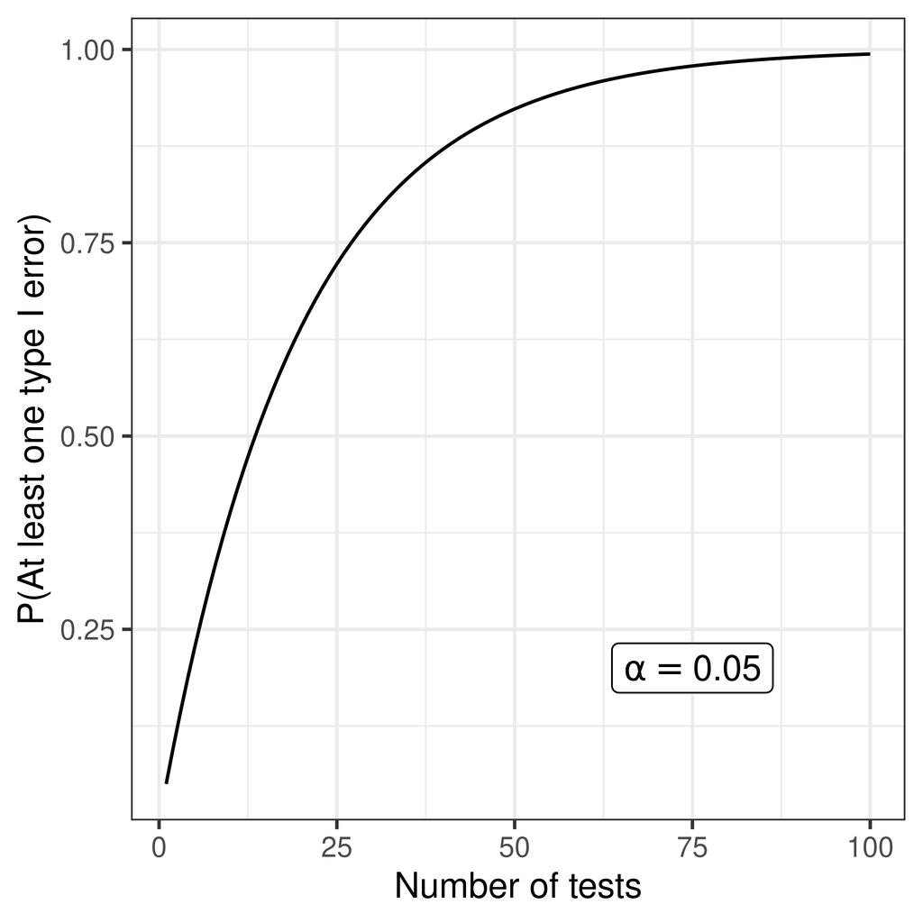

## Multiple testing correction

- FWER: family-wise error rate, control the probability of one or more false positive $P(N_{FP}>0)$, e.g. Bonferroni, Holm
- FDR: false discovery rate, control the expected value of the proportion of false positives among hits, $E[N_{FP}/(N_{FP}+N_{TP})]$, e.g. Benjamini-Hochberg, Storey

## Bonferroni correction

To achieve a family-wise error rate of $FWER \leq \gamma$ when performing $m$ tests, declare significance and reject the null hypothesis for any test with $p \leq \gamma/m$.

Objections: too conservative

## Benjamini-Hochbergs FDR

|  | H0 is true | H0 is false |
| --- | --- | --- |
| Accept H0 | TN | FN |
| Reject H0 | FP | TP |

The false discovery rate is the proportion of false positives among ‘hits’, i.e. $\frac{FP}{TP+FP}$.

Benjamini-Hochberg’s method control the FDR level, $\gamma$, when performing $m$ *independent* tests, as follows:

1. Sort the p-values $p_1 \leq p_2 \leq \dots \leq p_m$.
2. Find the maximum $j$ such that $p_j \leq \gamma \frac{j}{m}$.
3. Declare significance for all tests $1, 2, \dots, j$.

## ‘Adjusted’ p-values

Sometimes an adjusted significance threshold is not reported, but instead ‘adjusted’ p-values are reported.

- Using Bonferroni’s method the ‘adjusted’ p-values are:

  $\tilde p_i = \min(m p_i, 1)$.

A feature’s adjusted p-value represents the smallest FWER at which the null hypothesis will be rejected, i.e. the feature will be deemed significant.

- Benjamini-Hochberg’s ‘adjusted’ p-values are called $q$-values:

  $q_i = \min(\frac{m}{i} p_i, 1)$

  A feature’s $q$-value can be interpreted as the lowest FDR at which the corresponding null hypothesis will be rejected, i.e. the feature will be deemed significant.

## Example, 10000 independent tests (e.g. genes)

| p-value | adj p (Bonferroni) | q-value (B-H) |
| --- | --- | --- |
| 1.7e-08 | 0.0002 | 0.0002 |
| 5.8e-08 | 0.0006 | 0.0003 |
| 3.4e-07 | 0.0034 | 0.0011 |
| 9.1e-07 | 0.0091 | 0.0020 |
| 1e-06 | 0.0100 | 0.0020 |
| 2.4e-06 | 0.0240 | 0.0040 |
| 2.3e-05 | 0.2300 | 0.0329 |
| 3.6e-05 | 0.3600 | 0.0450 |
| 0.00022 | 1.0000 | 0.2300 |
| 0.00023 | 1.0000 | 0.2300 |
| 0.00073 | 1.0000 | 0.6636 |
| 0.0032 | 1.0000 | 1.0000 |
| 0.0045 | 1.0000 | 1.0000 |
| 0.0087 | 1.0000 | 1.0000 |
| 0.0089 | 1.0000 | 1.0000 |
| 0.012 | 1.0000 | 1.0000 |
| 0.014 | 1.0000 | 1.0000 |
| 0.045 | 1.0000 | 1.0000 |
| 0.08 | 1.0000 | 1.0000 |
| 0.23 | 1.0000 | 1.0000 |